# Analyzing and Visualizing Data

```python
import matplotlib
import matplotlib.pyplot as plt
import pandas as pd
import seaborn as sns
import numpy as np

%matplotlib inline
```

# Intruduction

WeRateDogs Twitter archive is great, but it only contains very basic tweet information. Additional gathering, then assessing and cleaning was required for preparing the data for analyses and visualizations.

```python
df_master = pd.read_csv('twitter_archive_master.csv')
df_master.head()
```

|  | Unnamed: 0 | tweet_id | in_reply_to_status_id_x | in_reply_to_user_id_x | timestamp | source_x | text | expanded_urls | rating_10_scaled | dog_name | ... | img_num | p1 | p1_conf | p1_dog | p2 | p2_conf | p2_dog | p3 | p3_conf | p3_dog |
| --- | --- | --- | --- | --- | --- | --- | --- | --- | --- | --- | --- | --- | --- | --- | --- | --- | --- | --- | --- | --- | --- |
| 0 | 0 | 892420643555336193 | NaN | NaN | 2017-08-01 16:23:56 | Twitter for iPhone | This is Phineas. He's a mystical boy. Only eve... | https://twitter.com/dog_rates/status/892420643... | 13.0 | Phineas | ... | NaN | NaN | NaN | NaN | NaN | NaN | NaN | NaN | NaN | NaN |
| 1 | 1 | 892177421306343426 | NaN | NaN | 2017-08-01 00:17:27 | Twitter for iPhone | This is Tilly. She's just checking pup on you.... | https://twitter.com/dog_rates/status/892177421... | 13.0 | Tilly | ... | 1.0 | Chihuahua | 0.323581 | True | Pekinese | 0.090647 | True | Papillon | 0.068957 | True |
| 2 | 2 | 891815181378084864 | NaN | NaN | 2017-07-31 00:18:03 | Twitter for iPhone | This is Archie. He is a rare Norwegian Pouncin... | https://twitter.com/dog_rates/status/891815181... | 12.0 | Archie | ... | 1.0 | Chihuahua | 0.716012 | True | Malamute | 0.078253 | True | Kelpie | 0.031379 | True |
| 3 | 3 | 891689557279858688 | NaN | NaN | 2017-07-30 15:58:51 | Twitter for iPhone | This is Darla. She commenced a snooze mid meal... | https://twitter.com/dog_rates/status/891689557... | 13.0 | Darla | ... | 1.0 | Paper towel | 0.170278 | False | Labrador retriever | 0.168086 | True | Spatula | 0.040836 | False |
| 4 | 4 | 891327558926688256 | NaN | NaN | 2017-07-29 16:00:24 | Twitter for iPhone | This is Franklin. He would like you to stop ca... | https://twitter.com/dog_rates/status/891327558... | 12.0 | Franklin | ... | 2.0 | Basset | 0.555712 | True | English springer | 0.225770 | True | German short-haired pointer | 0.175219 | True |

5 rows × 54 columns

## I. Find the most popular dog names

The most often tweeted dognames are Charlie, Lucy, Oliver and Cooper. Other names such as Lola, Daisy and Bella are also qiet popular.

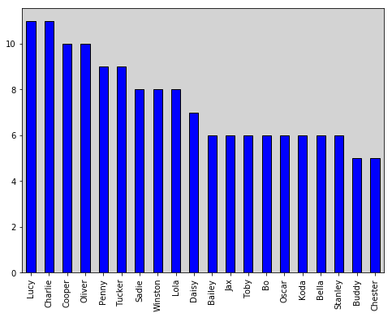

```python
fig, ax = plt.subplots(figsize=(8,6))

df_master['dog_name'].value_counts().head(20).plot(kind = 'bar', color = "blue", ax = ax, edgecolor = ['Black'])
ax.set_facecolor('lightgrey')
plt.show();
```

## II. Most Beloved Dog Breeds

I analyzed the relationship between tfavorite_counte and dog breeds p1 to find out which dog breeds are the most beloved by the users.

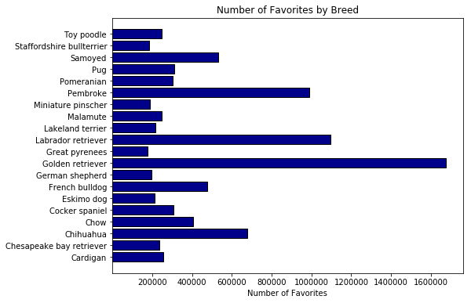

```python
# Creating a favorite dataframe by the groupped breeds, counted the favorites.
df_favorite_count = df_master.groupby('p1')['favorite_count'].sum().reset_index()
df_sorted = df_favorite_count.sort_values('favorite_count', ascending=False).head(20)
fav = df_sorted['favorite_count']
breed = df_sorted['p1']

fig, ax = plt.subplots(figsize=(8,6))
fav = plt.barh(breed, fav, color = "darkblue", edgecolor = ['Black']*len(breed))
plt.xlabel('Number of Favorites')
plt.title('Number of Favorites by Breed')
plt.xticks(np.arange(200000, 1800000, 200000))
plt.show();
```

## III. Dog Stages

I analyzed the specific "dog stages", excluding the missing values to make a pie chart about the proportions of the categories. The most often used stage is "pupper" with more than 65%, the second one is "doggo" (about 22%). The account owners use the words puppo and floofer in 10% of the cases alltogether.

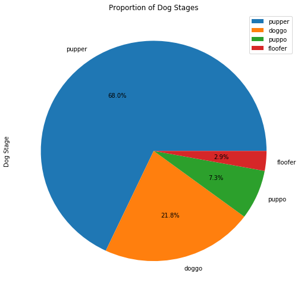

```python
# Exclude the cases where the dog stage is missing.
df_stage = df_master[df_master['stages'] != "None"]
fig, ax = plt.subplots(figsize=(8.5,8.5))

df_stage['stages'].value_counts().plot(kind = 'pie', ax = ax, label = 'Dog Stage', autopct='%1.1f%%')
plt.title('Proportion of Dog Stages')
plt.legend()
```

## IIII. Most Rated Breeds

I analyzed the relationship between ratings and dog breeds p1 to find out which dog breeds are the most rated.

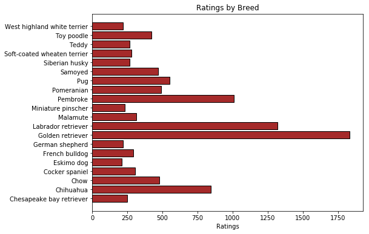

```python
# Exclude the negative or null values from the dataframe
df_ratings = df_master[df_master['rating_10_scaled'] > 0]
df_ratings = df_master.groupby('p1')['rating_10_scaled'].sum().reset_index()
df_sorted2 = df_ratings.sort_values('rating_10_scaled', ascending=False).head(20)
rating = df_sorted2['rating_10_scaled']
breed = df_sorted2['p1']

fig, ax = plt.subplots(figsize=(8,6))
fav = plt.barh(breed, rating, color = "brown", edgecolor = ['Black']*len(breed))
plt.xlabel('Ratings')
plt.title('Ratings by Breed')
plt.show();
```

## V. The relation between rating and vote count for the top twenty breeds

- I wanted to discover if the top rated breeds have a high favorite count from the users or not.
- The figure shows that the most rated breeds tend to have a high vote count as well.

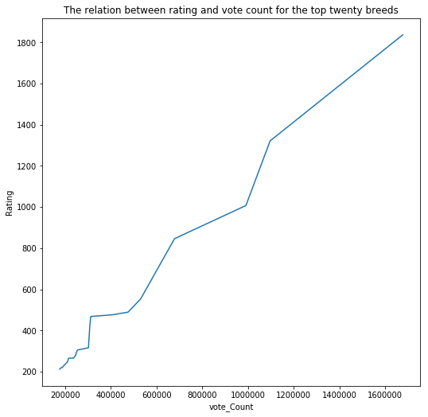

```python
fig, ax = plt.subplots(figsize=(8.5,8.5))

plt.plot(df_sorted['favorite_count'], rating)
plt.title('The relation between rating and vote count for the top twenty breeds')
plt.xlabel('vote_Count')
plt.ylabel('Rating')
plt.show()
```

## IV. Discover Correlations

- There is no correlation between rating and favorite count and retweet count.

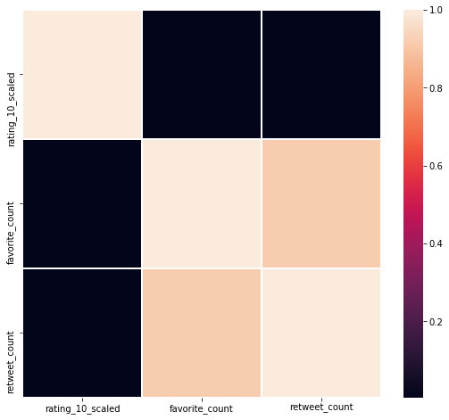

```python
# Creating a smaller df with the numerical values to make a hetmap matrix of the correlations
df_corr_values = df_master[['rating_10_scaled', 'favorite_count', 'retweet_count']]

fig, ax = plt.subplots(figsize=(9,8))
correlation = df_corr_values.corr()

sns.heatmap(correlation,
            xticklabels=correlation.columns.values,
            yticklabels=correlation.columns.values,
            ax=ax,
            linewidth= 0.5);
```

# Conclusions

I got some interesting finding related to the Twitter account WeRateDogs. Among those findings were the most popular dog names, the most beloved dog breeds, percentage of dog stages, the most rated breeds, the relation between rating and vote count for the top breeds and discovering that there is no correlation between rating and favorite count and retweet count.

# Sources

- https://en.wikipedia.org/wiki/WeRateDogs
- https://twitter.com/dog_rates